# Ford GoBike Usage Pattern

> *by Mohamed BOUSETTA MAHJOUB*

## Investigation Overview

In this investigation of the Ford GoBike System, I wanted to look at trip distribution and the most common user behaviors and characteristics, specifically how user type, time, gender, and age impacts usage of the system.

## Dataset Overview

This dataset includes information about individual rides made in a bike-sharing system covering the greater San Francisco Bay area. The data consisted of ride duration and attributes of appoximately 180,000 individual rides. The attributes included information about ride time and stations, as well as additional information about users such as type, gender, birth year. Some data points were removed from the analysis due to inconsistencies or missing information. New features were added like start_day_week, start_hour, member_age, age_groups .

## Distribution of Rides by User Type & Gender

The Pie plots below show the usage of Ford GoBike system by User Type and Gender :

- Subscribers contributed the majority of the bike usage, about 90%, while about 10% were consumed by cusomters (or casual users)
- Most riders were male.

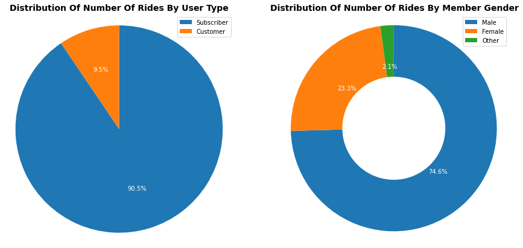

## Distribution of Rides by Age

The number of rides depends on user age. The bar plots below shows a huge usage of the bike share system by young adults (25-34 years old) espacially 31 years old riders.

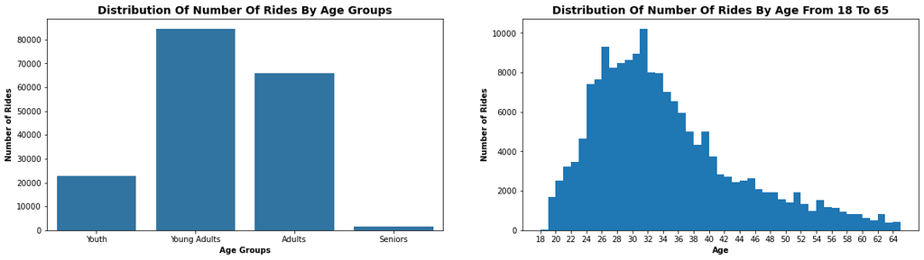

## Distribution of Rides by Time

Locking at the charts below, we find that the trip distribution over day hours peaks around two timeframes, 7am-10am and 16pm-19pm, during typical rush hours. Looking in combined with the trip distribution over day of week plot, it is quite obvious that the majority of rides happened on work days (Mon-Fri).

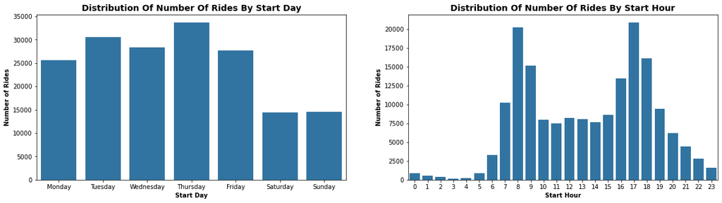

## Distribution of Ride Durations

Duration has a long-tailed distribution, with a lot of rides on the low duration end, and few on the high duration end. the proportion of outliers is 5.33%, that means 94.67% of rides were less than 1488s

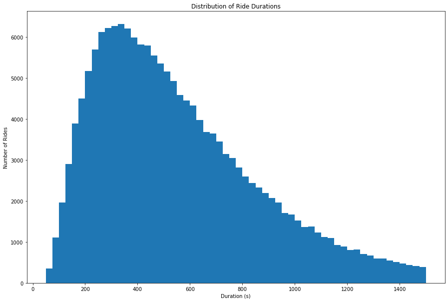

When plotted on a log-scale, the duration distribution looks like normal distribution, with one peak aroud 500s. we could reduce the proportion of outliers to 1.5%.

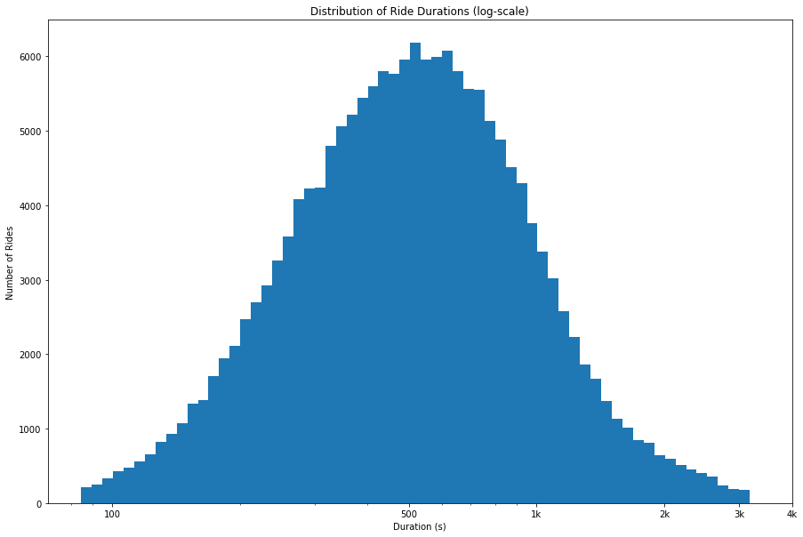

## Distribution of Ride Durations by User Type, Gender and Age Groups

The charts below show clearly the relationship between the main feature ride duration and the categoric features. we can see that subscriber ride duration is smaller than Customer and male riders tend to have shorter trips compared to female users. We find also that young male subcribers are the fastest riders and female senior customers are the slowest.

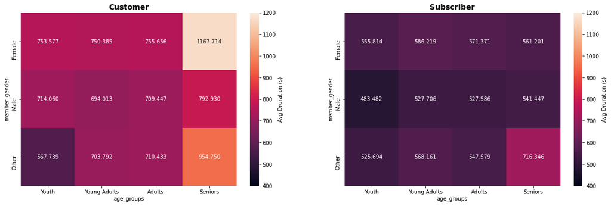

## Distribution of Ride Durations During Weekdays

We can see that when we remove the outliers, the ride duration average is the same all the week. Taking in consideration the outliers, The riding trips are much shorter on Monday through Friday compared to weekends. It indicates a pretty stable and efficient usage of the sharing system on normal work days, while more casual flexible use on weekends.

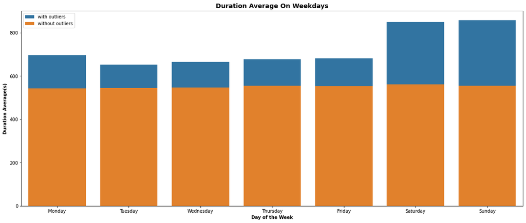

## Distribution of Ride Durations by Hours

the chart below shows that :

- Ride duration average is smaller and more stable duraing the rush hours
- The average usage time shown an increasing trend during normal hours

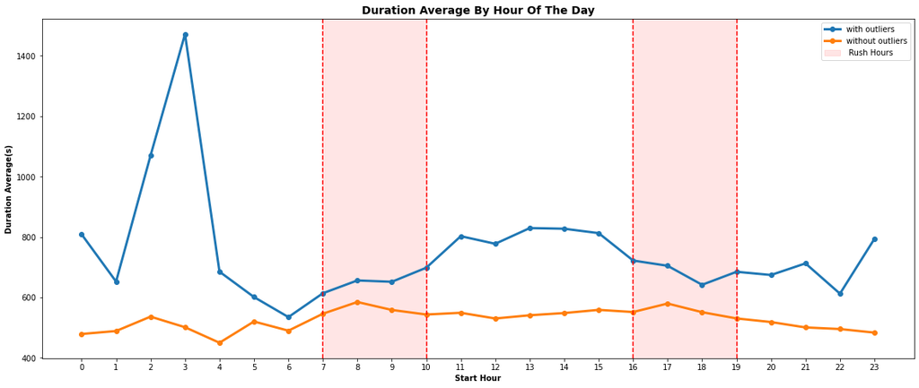